# exFINDER identifies differentiation-associated external signals during zebrafish neural crest (NC) development.

### Visualize the exSigNet via hierarchy plot

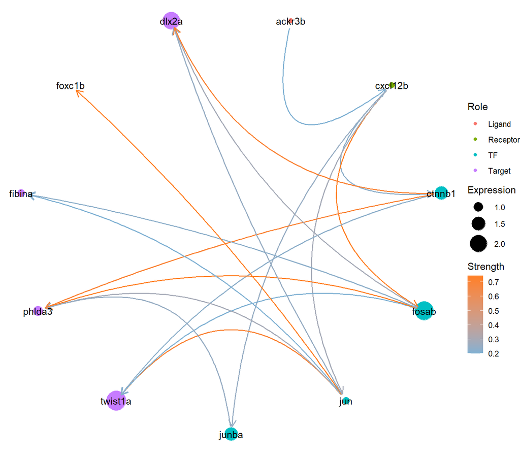

```r
# hierarchy plot
exSigNet_plot <- get_readyforplot(Graph = exSigNet)

p <- ggraph(exSigNet_plot[[1]], layout = 'dendrogram', circular = TRUE) +
  geom_node_point(aes(filter = leaf, x=x, y=y, colour=Role, size=Expression)) +
  theme_void() +
  geom_conn_bundle(data = get_con(from = exSigNet_plot[[2]]$from,
                                  to = exSigNet_plot[[2]]$to,
                                  Strength = exSigNet_plot[[2]]$weight), width = 0.7, aes(colour=Strength),
                   arrow = arrow(length = unit(3, 'mm')), start_cap = circle(3, 'mm'), end_cap = circle(3, 'mm')) +
  scale_edge_color_continuous(low="#80b1d3", high="#FF7F24")+
  geom_node_text(aes(label = node)) +
  scale_size_continuous( range = c(0.1,10) )
p
```

```r
# ggsave(p, filename="Fig_3g.pdf")
```

# Part IV: Infer the critical transition signal-related exSigNet

*critical transition signals (CTS)* refer to a group of transcription factors (TFs) that drive the critial transition. Here we infer the exSigNet that: (1) activated by the ligands that come from ecternal environment; (2) the TFs are critical transition signals; (3) the target genes are marker genes of skeletal and pigment cells.

The analysis of critical transition and inference of CTS is done using BioTIP (based on the official workflow). BioTIP (Xinan H Yang, et al. Nucleic Acids Research, 2022): https://bioconductor.org/packages/release/bioc/vignettes/BioTIP/inst/doc/BioTIP.html

## Load CTS and set-up target genes

```r
# the list of CTS genes can be downloaded from: https://figshare.com/s/bd69667e5b17d957a84e
# (the corresponding IC values can be downloaded from: https://figshare.com/s/d36391b85a6ab2c95911)
CTS.Z <- read.csv(file = "/Users/chang/Documents/exFINDER/testdata/Tatarakis2021_Zebrafish_CTS.csv")

markerS <- read.csv(file = "../markers/Tatarakis2021_Zebrafish_marker/Tatarakis2021_Zebrafish_markers_skeletal.csv")
markerP <- read.csv(file = "../markers/Tatarakis2021_Zebrafish_marker/Tatarakis2021_Zebrafish_markers_pigment.csv")
target.SP <- c(markerS$X[1:5], markerP$X[1:5])
```

## Infer exSigNet (denoted as exSigNet.4)

```r
# infer ltGRN
ltGRN.3 <- get_ltGRN(Target = target.SP, DB = exFINDER.Z)
```

```r
# infer potential external signals from ltGRN
Pex.3 <- get_potentialex(Graph = ltGRN.3,
                Exp.Data = exp.Exdata,
                Meta.Data = meta.Exdata,
                cutoff = -0.01,
                AG.L = NULL)

# infer exSigNet (R, TF, T are all highly expressed, L comes from the potential external signals)
# here, we are interested in the existance of the exSigNet that associated to the CTS, so we set the cutoff values to be relatively low
exSigNet.3 <- get_exSigNet(Graph = ltGRN.3,
                       Ligands = Pex.3,
                       Exp.Data = exp.data,
                       Meta.Data = meta.data,
                       par.cutoff = c(0.5, 0.01),
                       AG.R = c("skeletal", "transition", "pigment"),
                       AG.TF = c("skeletal", "transition", "pigment"))
```

```
#> [1] "No overlap found!"
```

if overlap is detected in an exSigNet, we shall fix it by running “fix_Overlap”

```r
exSigNet.3 <- fix_OverLap(exSigNet.3)
```

```
#> [1] "No overlap found!"
```

check what CTS are inferred in the exSigNet

```r
intersect(exSigNet.3$Graph.Node$Gene[exSigNet.3$Graph.Node$Role == "TF"], CTS.Z$x)
```

```
#> [1] "tal1" "lmo2"
```

infer the exSigNet that all TFs are CTS by running “get_subNet”

```r
exSigNet.4 <- get_subNet(Graph = exSigNet.3,
           TF = c("tal1", "lmo2"))
exSigNet.4
```

```
#> $Graph.Edge
#>        from      to   source           path from.Role  to.Role
#> 1      igf1   rack1 NicheNet     igf1*rack1    Ligand Receptor
#> 2  itgb1b.2   rack1 NicheNet itgb1b.2*rack1    Ligand Receptor
#> 3     gdnfa  agtrap NicheNet   gdnfa*agtrap    Ligand Receptor
#> 4     rack1    tal1 NicheNet     rack1*tal1  Receptor       TF
#> 5    agtrap    lmo2 NicheNet    agtrap*lmo2  Receptor       TF
#> 6      tal1 slc45a2 NicheNet   tal1*slc45a2        TF   Target
#> 7      tal1 twist1a NicheNet   tal1*twist1a        TF   Target
#> 8      lmo2  fibina NicheNet    lmo2*fibina        TF   Target
#> 9      lmo2     pts NicheNet       lmo2*pts        TF   Target
#> 10     tal1   dlx2a NicheNet     tal1*dlx2a        TF   Target
#>
#> $Graph.Node
#>         Gene     Role
#> 4       igf1   Ligand
#> 5   itgb1b.2   Ligand
#> 21     gdnfa   Ligand
#> 25     rack1 Receptor
#> 30    agtrap Receptor
#> 71      tal1       TF
#> 146     lmo2       TF
#> 148  slc45a2   Target
#> 152  twist1a   Target
#> 153   fibina   Target
#> 154      pts   Target
#> 156    dlx2a   Target
```

## Visualization

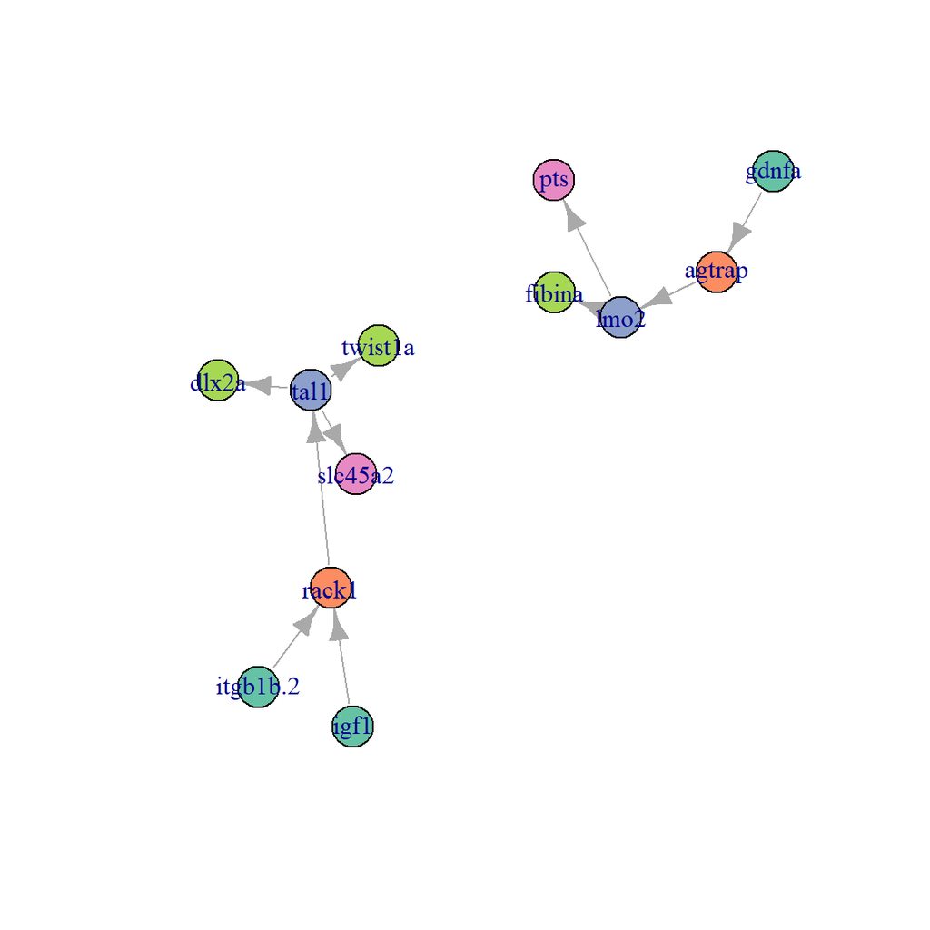

```r
library(igraph)
library(RColorBrewer)

exSigNet.4$Graph.Node$Role[exSigNet.4$Graph.Node$Gene %in% c("slc45a2", "pts")] = "Target (pigment)"
exSigNet.4$Graph.Node$Role[exSigNet.4$Graph.Node$Gene %in% c("twist1a", "fibina", "dlx2a")] = "Target (skeletal)"

actors <- data.frame(
  name = exSigNet.4$Graph.Node$Gene,
  role = exSigNet.4$Graph.Node$Role
)

relations <- data.frame(
  from = exSigNet.4$Graph.Edge$from,
  to = exSigNet.4$Graph.Edge$to
)

g <- graph_from_data_frame(
  relations, directed = TRUE,
  vertices = actors
)

l <- layout_with_gem(g)

coul  <- brewer.pal(5, "Set2")
# Create a vector of color
my_color <- coul[as.numeric(as.factor(V(g)$role))]

# pdf("CTS_Z_Network.pdf")
plot(g, layout=l, vertex.color=my_color)
```